# Student Housing Costs

## Background

Stephanie[^1] is a student that will be starting school at BYU-Idaho next semester. Here is a copy of the email request for information that she sent.

“Hi. My name is Stephanie. I would like to learn about what housing options I have for living at BYU-Idaho next semester. It will be my first semester there, so I would like to find something that is close to campus and around $300 a month in rent. I’m not too picky on roomates, but I would like somewhere that has a lot of people around so I can get to know as many people as possible. Thanks in advance!”

**My Response:**

Hello Stephanie,

I’ve compiled a list of approved housing for women from the [BYU-Idaho Housing Website](https://web.byui.edu/tis/search). This first table provides all results:

```r
womens <- subset(Rent, Gender=="F")
datatable(womens, extensions="Responsive", options=list(lengthMenu = c(3,10,30,57)))
```

|  | Apartment | Cost | CostHigh | Residents | Miles2Campus | WalkMinutes | ParkingStalls | Deposit | UtilityDeposit | FloorPlans | Gender | Latitude | Longitude | Address | Phone | Website | Description |
| --- | --- | --- | --- | --- | --- | --- | --- | --- | --- | --- | --- | --- | --- | --- | --- | --- | --- |
| 1 | ABBY LANE MANOR | 1035 | 1060 | 42 | 0.745647284 | 16 | 38 | 100 | 0 | 3 | F | 43.8169418 | -111.7952062 | 437 S 4TH W | (208) 359-3687 | www.abbylaneapartments.com | We are a small women's complex offering private rooms and quaint living. Many students enjoy our advantages enough that they stay with us until graduation. We are sure you would like staying with us! … |
| 4 | ABRI APARTMENTS - WOMEN | 1445 | 1495 | 150 | 0.310686368 | 8 | 216 | 150 | 0 | 3 | F | 43.8239342 | -111.7773062 | 220 E 1ST S | (208) 417-7223 | www.liveabri.com | $100 OFF SPECIAL! Look no further than the Abri, Rexburg's newest student housing community. Currently leasing women's spots for fall '17, &amp; men's for winter '18. From upscale, modern finishes, to… |
| 5 | ALBION APARTMENT | 1062.5 | 1150 | 5 | 0.186411821 | 4 | 4 | 100 | 0 | 3 | F | 43.8218385 | -111.7906463 | 231 W 2ND S | (801) 856-0732 |  | Cute, newly painted basement apartment across the street from Porter Park and 1.5 blocks from the Hart building. Utilities and Internet are free. Washer and Dryer included in the Apartment. There are … |
| 6 | ALEXANDER APARTMENT | 972.5 | 1115 | 22 | 0.434960916 | 8 | 18 | 100 | 0 | 10 | F | 43.8197811 | -111.7918951 | 276 W 3RD S | 208-995-8543 | www.alexanderapartments.wordpress.com | We are also signing for Fall and Winter 2017. Get $25 off per semester for signing 2 consecutive semesters. No application fee or parking fee and get $40 in quarters for laundry each semester. |
| 7 | ALLDREDGE HOUSE | 1045 | 1095 | 8 | 0.186411821 | 5 | 8 | 150 | 0 | 3 | F | 43.82073 | -111.780478 | 243 S 1ST E | 208-206-4697 |  | Hurry quick! Come make ALLDREDGE HOUSE your home away from home! Located directly across the street from the Clarke and Kirkham Buildings and only a few blocks away from down town. Great ward with the… |
| 10 | ALLEN'S SUNRISE VILLAGE - WOMEN | 1000 | 1075 | 144 | 0.062137274 | 1 | 133 | 100 | 0 | 3 | F | 43.82186 | -111.785197 | 48 W 2ND S | 208-356-3995 | www.sunrisevillageapts.com | We offer housing for both men and women! We are well-known for our friendliness, new modern remodel, low prices, great location, our fantastically reliable OPTIX internet and amazing managers. You'll … |
| 14 | AMERICAN AVENUE - WOMEN | 1050 | 1075 | 165 | 0.372823642 | 7 | 0 | 100 | 0 | 6 | F | 43.8228628 | -111.7807632 | 151 S 1ST E | (208) 356-5097 | myamericanavenue.com | American Avenue, BYU Idaho Approved Men and Women's housing, is less than a 1/2 block from campus. We have ample parking, FREE onsite laundry, Fiber Optix highspeed internet, 32" flat screen SONY TV's… |
| 19 | ASPEN VILLAGE - WOMEN | 900 | 1000 | 210 | 0.372823642 | 6 | 84 | 75 | 0 | 10 | F | 43.814649 | -111.778083 | 545 S 2ND E | (208) 356-7701 | www.aspenvillageapartments.com | Great management. Price. Location. Pool. Semester after semester, students tell us this is why they love and remain at Aspen Village! Located across from campus and the temple we offer great views, FR… |
| 20 | AT THE GROVE |  |  | 6 | 0.186411821 | 3 | 5 | 0 | 0 | 1 | F | 43.8185731 | -111.7766137 | 349 HARVARD AVE | 801-319-4334 | https://www.facebook.com/atthegroveapts/ | At The Grove is a spacious basement apartment, located just a stone's throw away from the east side of campus, and around the corner from the temple. Here you will enjoy the feeling of "home," with on… |
| 21 | AUTUMN WINDS | 1345 | 1345 | 96 | 0.434960916 | 9 | 96 | 75 | 0 | 1 | F | 43.8156171 | -111.7884885 | 160 W 5TH S | (208) 356-0821 | www.rexburghousing.com | Autumn Winds offers Private rooms with only 4 people per apartment! There are two bathrooms in each apartment and 4 sinks, so you will only share a bathroom with one other person, and have your own va… |

[output cut: 47 more lines]

The table supplied will allow you to sort the options if you click on the arrows.

Tip: Clicking “Miles2Campus”" once, and then “Cost” once will sort both low to high with cost being the first preference.

The “Miles2Campus” and suggested walking distances will give you an idea but are not all accurate.

Click the “+” buttons to view more details. It is useful to check the addresses on a map.

## Analysis

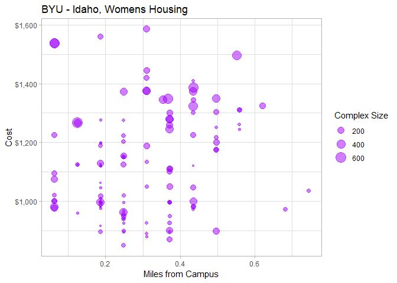

```r
#colorfade <- colorRampPalette(c("red", "green", "blue"))
#plot(Cost ~ Miles2Campus, data=Rent, col=colorfade(Rent$Residents))

ggplot(Rent, aes(y = Cost, x = Miles2Campus, size = Residents)) + theme_light() + geom_point(color = "#9f00FF", alpha = 0.5) +
  labs(x = "Miles from Campus", title = "BYU - Idaho, Womens Housing", size = "Complex Size") + scale_y_continuous(labels = scales::dollar)# + scale_colour_gradient2("Residents", low = "#00FFBB", mid = "#0000FF", high = "#BB00FF", midpoint = 200)
```

Since you said that you were looking to pay $300 a month, I reduced this new list to only the ones which are equivalent to $362 a month or less. I also removed any sites with a capacity of fewer than 30 residents.

```r
costwm <- subset(Rent, Gender=="F" & Cost<=1068.52 & Residents>=30)
datatable(costwm, extensions="Responsive", options=list(lengthMenu = c(5,13)))
```

|  | Apartment | Cost | CostHigh | Residents | Miles2Campus | WalkMinutes | ParkingStalls | Deposit | UtilityDeposit | FloorPlans | Gender | Latitude | Longitude | Address | Phone | Website | Description |
| --- | --- | --- | --- | --- | --- | --- | --- | --- | --- | --- | --- | --- | --- | --- | --- | --- | --- |
| 1 | ABBY LANE MANOR | 1035 | 1060 | 42 | 0.745647284 | 16 | 38 | 100 | 0 | 3 | F | 43.8169418 | -111.7952062 | 437 S 4TH W | (208) 359-3687 | www.abbylaneapartments.com | We are a small women's complex offering private rooms and quaint living. Many students enjoy our advantages enough that they stay with us until graduation. We are sure you would like staying with us! … |
| 10 | ALLEN'S SUNRISE VILLAGE - WOMEN | 1000 | 1075 | 144 | 0.062137274 | 1 | 133 | 100 | 0 | 3 | F | 43.82186 | -111.785197 | 48 W 2ND S | 208-356-3995 | www.sunrisevillageapts.com | We offer housing for both men and women! We are well-known for our friendliness, new modern remodel, low prices, great location, our fantastically reliable OPTIX internet and amazing managers. You'll … |
| 14 | AMERICAN AVENUE - WOMEN | 1050 | 1075 | 165 | 0.372823642 | 7 | 0 | 100 | 0 | 6 | F | 43.8228628 | -111.7807632 | 151 S 1ST E | (208) 356-5097 | myamericanavenue.com | American Avenue, BYU Idaho Approved Men and Women's housing, is less than a 1/2 block from campus. We have ample parking, FREE onsite laundry, Fiber Optix highspeed internet, 32" flat screen SONY TV's… |
| 19 | ASPEN VILLAGE - WOMEN | 900 | 1000 | 210 | 0.372823642 | 6 | 84 | 75 | 0 | 10 | F | 43.814649 | -111.778083 | 545 S 2ND E | (208) 356-7701 | www.aspenvillageapartments.com | Great management. Price. Location. Pool. Semester after semester, students tell us this is why they love and remain at Aspen Village! Located across from campus and the temple we offer great views, FR… |
| 24 | BIRCH PLAZA | 980 | 980 | 343 | 0.062137274 | 1 | 160 | 75 | 0 | 1 | F | 43.8209717 | -111.7867163 | 236 S 1ST W | (208) 359-8200 | www.rexburghousing.com | Some girls choose to spend all of their BYU-Idaho years living at Birch Plaza. That's how good it is. The wards are outstanding, and there's a sense of community that you'll find almost nowhere else. … |
| 25 | BIRCH WOOD I | 1019 | 1019 | 65 | 0.062137274 | 1 | 160 | 75 | 0 | 1 | F | 43.8209717 | -111.7867163 | 253 S 2ND W | (208) 359-8200 | www.rexburghousing.com | Birchwood I is a very special place. The ward is outstanding, as are the residents. There's a hot tub, an onsite full-service professional salon, and ample parking. A city park is one block away, and … |
| 33 | BROOKLYN APARTMENTS | 870 | 895 | 144 | 0.372823642 | 7 | 0 | 75 | 0 | 3 | F | 43.8188718 | -111.7895166 | 345 S 2ND W | 208-356-9500 | WWW.BROOKLYNAPTS.NET | Brooklyn Apartments is a wonderful place to live, study, meet new friends and grow. Living here makes socializing, getting to class and shopping easier as we are located in the heart of Rexburg and on… |
| 53 | COTTONWOOD-WOMEN | 950 | 950 | 84 | 0.248549095 | 5 | 100 | 75 | 0 | 1 | F | 43.8250778 | -111.7867042 | 42 S 1ST W | (208) 356-9576 | www.cottonwoodstudentapartments.com | Men and Women's Housing. super social, NEWLY RENOVATED and Free Laundry! Perfect for working students, great mix of all college ages. Beautiful courtyard, fruit trees, basketball court and fire pit. W… |
| 60 | DAVENPORT APARTMENTS | 895 | 895 | 71 | 0.186411821 | 4 | 30 | 0 | 0 | 3 | F | 43.819765 | -111.7879773 | 145 W 3RD S | 208-356-3216 | davenportapartments.net | Davenport has an ideal price and an ideal location. 1/2 block from campus. FREE LAUNDRY. Recently upgraded DEPENDABLE and FAST Fiber Optic Internet. We are well-known for our large living spaces, home… |
| 66 | GREENBRIER SOUTH | 981 | 981 | 92 | 0.434960916 | 9 | 70 | 125 | 0 | 1 | F | 43.823056 | -111.779371 | 129 PRINCETON CT | 356-3001 | www.bestnesthousing.com | Great location! We have a wonderful management team that works together with a maintenance crew, cleaning specialist, and on-site management. We really care about what is important to the students at … |

[output cut: 3 more lines]

## Interpretation

Any of the apartments may be worth your consideration. Birch Plaza is a popular choice. You might also consider Brookyln or Davenport for their price. The more expensice ones have some nice features, like Birch Wood I with its hot tub!

[^1]: Note that Stephanie is a fictional character who is based on real experiences of many faculty and staff here at BYU-Idaho.